# Time Series Analysis in R

```r
forecast <- forecast.Arima(arima, h=3, level=c(99.5))
forecast
```

```
##      Point Forecast   Lo 99.5  Hi 99.5
## 1970       21.48131 -175.0288 217.9914
## 1971       37.66419 -208.3686 283.6970
## 1972       47.13261 -213.7018 307.9670
```

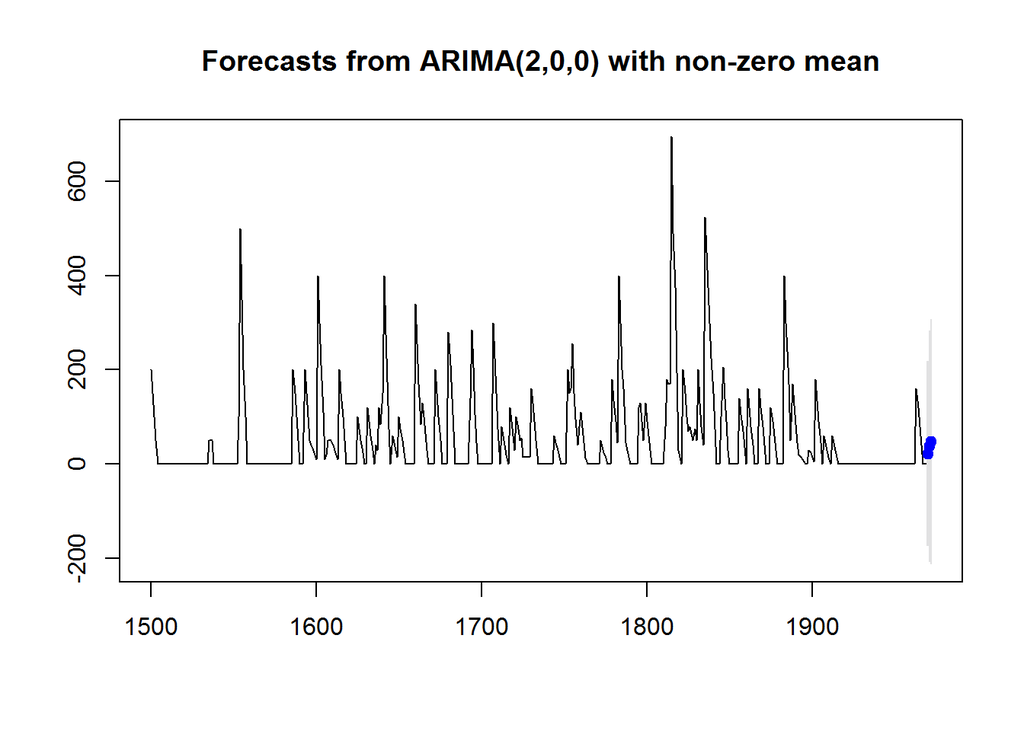

```r
plot.forecast(forecast)
```

```r
Box.test(forecast$residuals, type="Ljung-Box",lag=6)
```

```
##
##  Box-Ljung test
##
## data:  forecast$residuals
## X-squared = 4.8047, df = 6, p-value = 0.5691
```

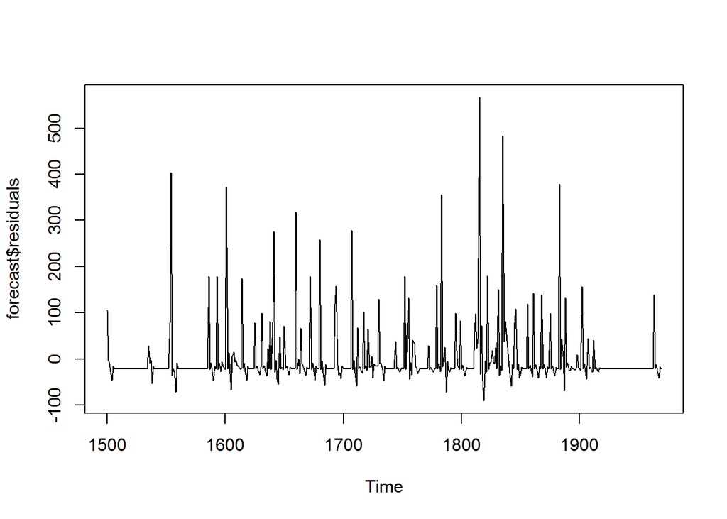

```r
plot.ts(forecast$residuals)
```

### 4.4 Forecasting Using an ARIMA Model

#### 4.4.1 Example of the Ages at Death of the Kings of England

```r
kingstimeseriesarima <- arima(kingstimeseries, order=c(0,1,1)) # fit an ARIMA(0,1,1) model
kingstimeseriesarima
```

```
##
## Call:
## arima(x = kingstimeseries, order = c(0, 1, 1))
##
## Coefficients:
##           ma1
##       -0.7218
## s.e.   0.1208
##
## sigma^2 estimated as 230.4:  log likelihood = -170.06,  aic = 344.13
```

- **Specifying the confidence level for prediction intervals.** You can specify the confidence level for prediction intervals in forecast.Arima() by using the “level” argument. For example, to get a 99.5% prediction interval, we would type “forecast.Arima(kingstimeseriesarima, h=5, level=c(99.5))”

```r
# library(forecast)
kingstimeseriesforecasts <- forecast.Arima(kingstimeseriesarima, h=5)
kingstimeseriesforecasts
```

```
##    Point Forecast    Lo 80    Hi 80    Lo 95     Hi 95
## 43       67.75063 48.29647 87.20479 37.99806  97.50319
## 44       67.75063 47.55748 87.94377 36.86788  98.63338
## 45       67.75063 46.84460 88.65665 35.77762  99.72363
## 46       67.75063 46.15524 89.34601 34.72333 100.77792
## 47       67.75063 45.48722 90.01404 33.70168 101.79958
```

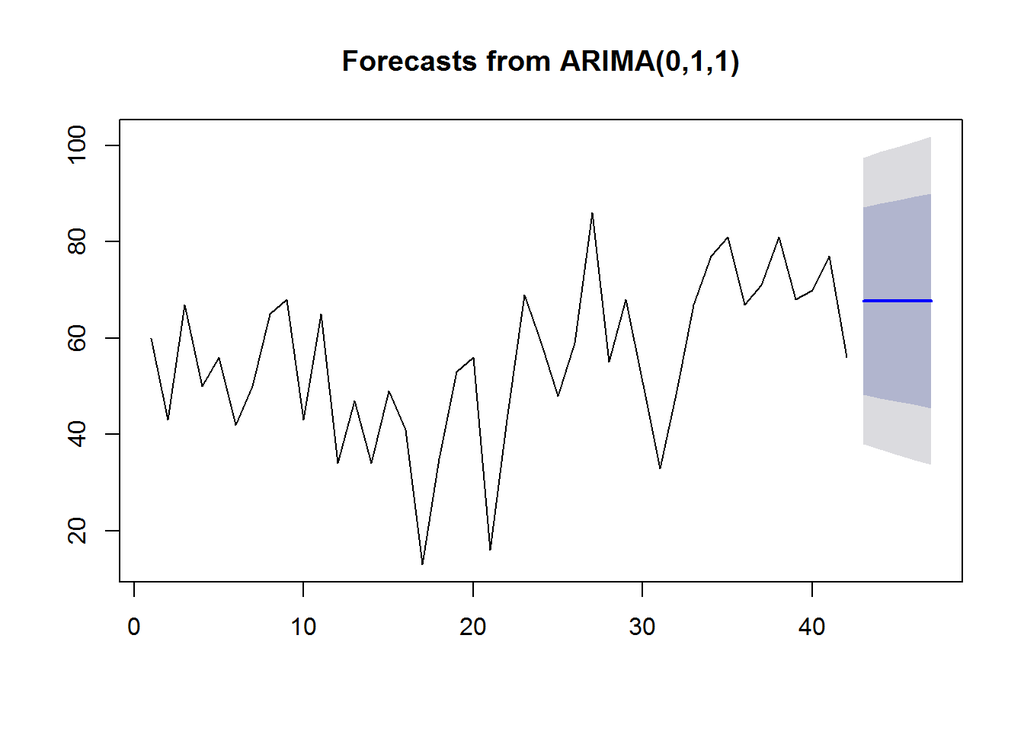

```r
plot.forecast(kingstimeseriesforecasts)
```

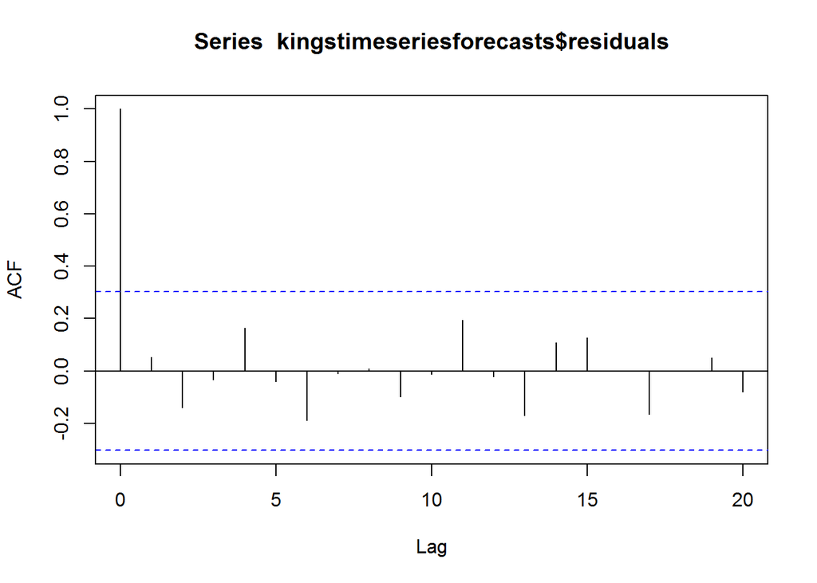

```r
acf(kingstimeseriesforecasts$residuals, lag.max=20)
```

```r
Box.test(kingstimeseriesforecasts$residuals, lag=20, type="Ljung-Box")
```

```
##
##  Box-Ljung test
##
## data:  kingstimeseriesforecasts$residuals
## X-squared = 13.584, df = 20, p-value = 0.8509
```

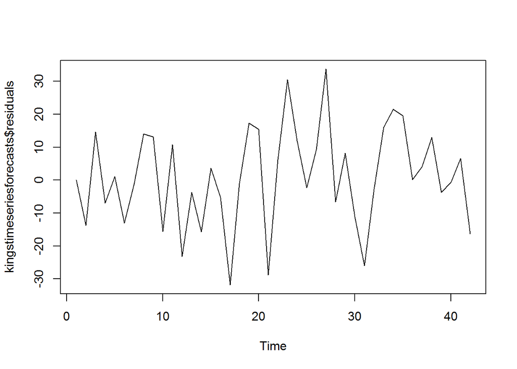

```r
plot.ts(kingstimeseriesforecasts$residuals)
```

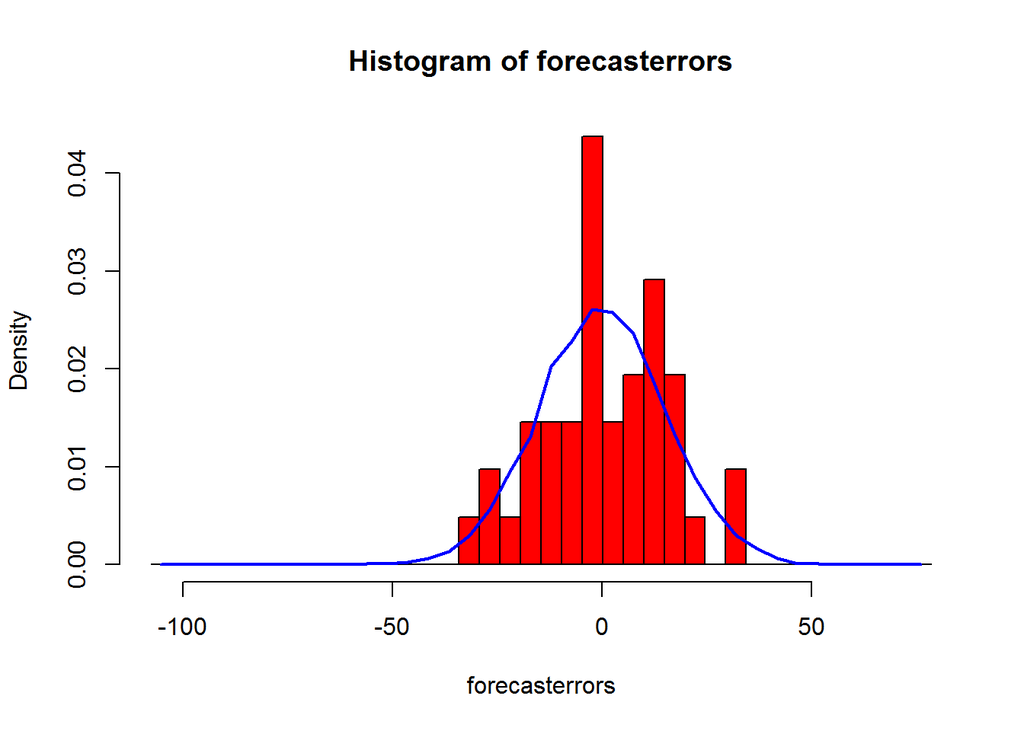

```r
plotForecastErrors(kingstimeseriesforecasts$residuals)
```

- Since successive forecast errors do not seem to be correlated, and the forecast errors seem to be normally distributed with mean zero and constant variance, the ARIMA(0,1,1) does seem to provide an adequate predictive model for the ages at death of English kings
- Since the correlogram shows that none of the sample autocorrelations for lags 1-20 exceed the significance bounds, and the p-value for the Ljung-Box test is 0.9, we can conclude that there is very little evidence for non-zero autocorrelations in the forecast errors at lags 1-20.

#### 4.4.2 Example of the Volcanic Dust Veil in the Northern Hemisphere

```r
volcanodustseriesarima <- arima(volcanodustseries, order=c(2,0,0))
volcanodustseriesarima
```

```
##
## Call:
## arima(x = volcanodustseries, order = c(2, 0, 0))
##
## Coefficients:
##          ar1      ar2  intercept
##       0.7533  -0.1268    57.5274
## s.e.  0.0457   0.0458     8.5958
##
## sigma^2 estimated as 4870:  log likelihood = -2662.54,  aic = 5333.09
```

```r
volcanodustseriesforecasts <- forecast.Arima(volcanodustseriesarima, h=3)
volcanodustseriesforecasts
```

```
##      Point Forecast     Lo 80    Hi 80     Lo 95    Hi 95
## 1970       21.48131 -67.94860 110.9112 -115.2899 158.2526
## 1971       37.66419 -74.30305 149.6314 -133.5749 208.9033
## 1972       47.13261 -71.57070 165.8359 -134.4084 228.6737
```

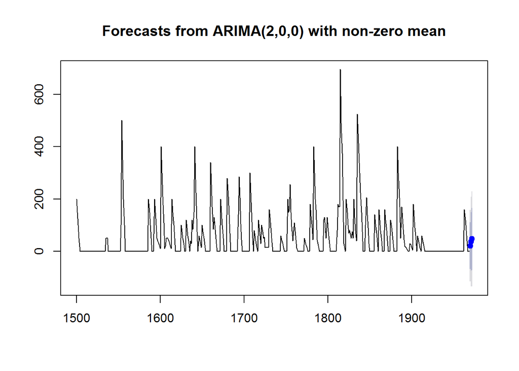

```r
plot.forecast(volcanodustseriesforecasts)
```

- One worrying thing is that the model has predicted negative values for the volcanic dust veil index, but this variable can only have positive values! The reason is that the arima() and forecast.Arima() functions don’t know that the variable can only take positive values. Clearly, this is not a very desirable feature of our current predictive model

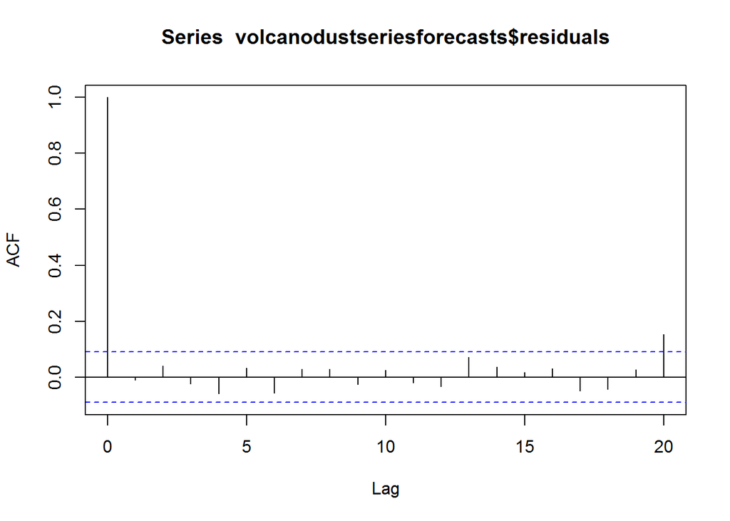

```r
acf(volcanodustseriesforecasts$residuals, lag.max=20)
```

```r
Box.test(volcanodustseriesforecasts$residuals, lag=20, type="Ljung-Box")
```

```
##
##  Box-Ljung test
##
## data:  volcanodustseriesforecasts$residuals
## X-squared = 24.364, df = 20, p-value = 0.2268
```

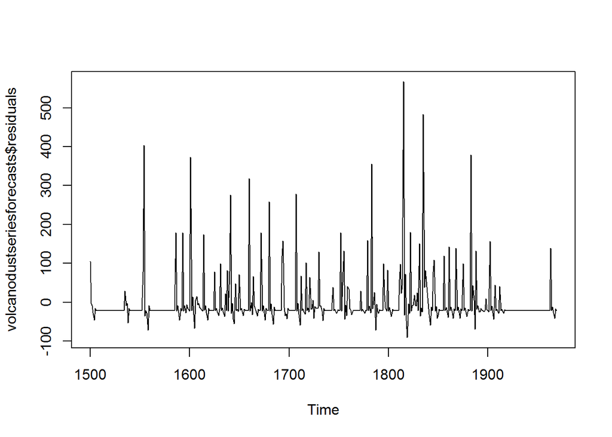

```r
plot.ts(volcanodustseriesforecasts$residuals)
```

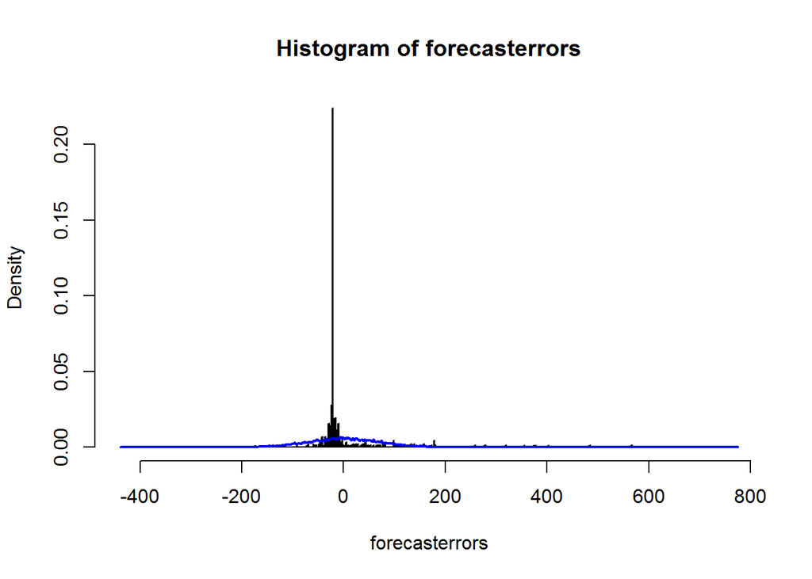

```r
plotForecastErrors(volcanodustseriesforecasts$residuals)
```

```r
mean(volcanodustseriesforecasts$residuals)
```

```
## [1] -0.2205417
```

- The histogram of forecast errors (above) shows that although the mean value of the forecast errors is negative, the distribution of forecast errors is skewed to the right compared to a normal curve. Therefore, it seems that we cannot comfortably conclude that the forecast errors are normally distributed with mean zero and constant variance! Thus, it is likely that our ARIMA(2,0,0) model for the time series of volcanic dust veil index is not the best model that we could make, and could almost definitely be improved upon!